# NOSE study

Scott Coggeshall

6/18/2020

## Basic Data Unit: the 2x2 Table

Let $T_1$ and $T_2$ stand for the binary results of the SoC and Alt swab, respectively, where 1 indicates presence of disease $D$ and 0 indicates absence of disease.

The basic unit of observed data at the site level is a two-by-two table of the cross-classified results of the two tests. This can be fully described in terms of the 4 probabilities:

$$\begin{align*}
p_{00} &= P(T_1 = 0, T_2 = 0) \\
p_{01} &= P(T_1 = 0, T_2 = 1) \\
p_{10} &= P(T_1 = 1, T_2 = 0) \\
p_{11} &= P(T_1 = 1, T_2 = 1)
\end{align*}$$
where $p_{00} + p_{01} + p_{10} + p_{11} = 1$.

Quantities of interest regarding the agreement between the two tests can be computed from this table, i.e. overall agreement can be calculated as

$$P(Agree) = p_{00} + p_{11}.$$

## Direct Empirical Approach

One possible approach is to ignore any consideration of the underlying characteristics of the tests and just work directly with these observed quantities. For instance, we can model the observed agreement between the tests at a given site as

$$N_{Agree} \sim Binomial(n, P(Agree))$$

and then base power/sample size calculations on the hypothesis test

$$H_0: P(Agree) < .95 \qquad H_1: P(Agree) \geq .95$$

Power curves to detect agreement above $95\%$ at different samples sizes are shown below

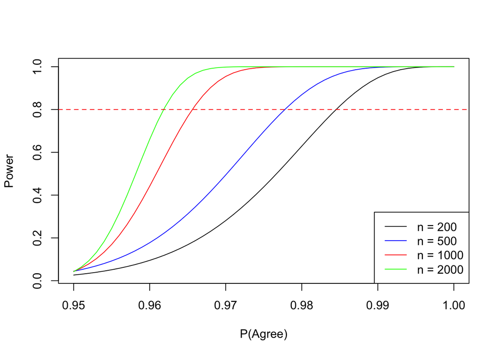

Consideration of the sample size needed to achieve good frequentist properties for detecting certain effects of interest can serve as a guide for setting target sample sizes.

## Incorporating Information/Uncertainty about Underlying Prevalence and Test Performance

Rather than only considering the observed cell counts and the cell probabilities, we propose to work from a “generative” model in which we model the identified probabilities that generate the observed 2x2 table in terms of the (unidentified) underlying disease prevalence and true sensitivity/specificities of the SoC and Alt swabs.

Let $p_D$ stand for underlying disease prevalence among the population being tested and let $Sens_{t}$ and $Spec_{t}$ stand for the *true* sensitivity and specificity of test $T_t, t = 0, 1$. For example, $Sens_1 = P(Test_1 = 1 \mid D = 1)$ We can express the cell probabilities $p_{00}, p_{01}, p_{10}, p_{11}$ in terms of these underlying disease prevalence and test characteristics. We show the full derivation for $p_{00} = P(Test_1 = 0, Test_2 = 0)$ and then state the results for the remaining cell probabilities since they are derived in a similar manner.

$$\begin{align*}
P(Test_1 = 0, Test_2 = 0) &= P(Test_1 = 0, Test_2 = 0 \mid D = 1)P(D = 1) \\
&\qquad+ P(Test_1 = 0, Test_2 = 0 \mid D = 0)P(D = 0) \\
&= P(Test_1 = 0 \mid D = 1)P(Test_2 = 0 \mid Test_1 = 0, D = 1)P(D = 1)\\
&\qquad + P(Test_1 = 0 \mid D = 0) P(Test_2 = 0 \mid Test_1 = 0, D = 0)P(D = 0) \\
&= (1 - Sens_1)\times(1 - Sens_2)\times p_D + Spec_1 \times Spec_2 \times (1 - p_D).
\end{align*}$$

The full set of equations relating the cell probabilities $p_{00}, p_{01}, p_{10}, p_{11}$ to underlying disease prevalence and test characteristics is given by
$$\begin{align*}
p_{00} &= (1 - Sens_1) \times (1 - Sens_2) \times p_D + Spec_1 \times Spec_2 \times (1 - p_D) \\
p_{01} &= (1 - Sens_1)\times Sens_2 \times p_D + Spec_2 \times (1 - Spec_1) \times (1 - p_D)\\
p_{11} &= Sens_1 \times Sens_2 \times p_D + (1 - Spec_1) \times (1 - Spec_2) \times (1 - p_D)
\end{align*}$$

We leave off the final probability $p_{10}$ since it is determined by the other three through the requirement that $p_{00} + p_{01} + p_{10} + p_{11} = 1.$

Under an assumption of *conditional independence*

$$\begin{align*}
P(T_2 \mid T_1, D) &= P(T_2 \mid D)
\end{align*}$$

then $Sens_2$ and $Spec_2$ correspond to the unconditional sensitivity and specificity of the second test. In the presence of an order effect, we would not expect the conditional independence assumption to hold. In that case, $Sens_2$ and $Spec_2$ correspond to a conditional sensitivity and specificity.

The key to using this approach is to work within a Bayesian framework where we specify our prior knowledge about the underlying parameters in terms of probability distributions, and then use the data to update that knowledge.

## Prior Specification

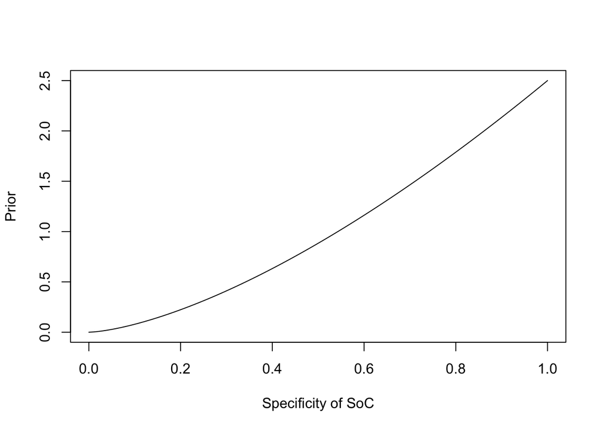

This distribution encodes our prior belief, based on our understanding of the science behind the SoC swab, that higher values for the specificity of the SoC swab are more plausible than lower.

Priors for the other parameters can be formed in a similar way by considering the range of values we consider to be plausible. If we really don’t have any prior knowledge about one of the parameters, we can specify a “flat” prior in which all values are considered equally probable.

## Likelihood

We then need to specify a likelihood, a model for the process by which the observed data arise as a function of the unobserved parameters.

Let the observed data be represented by $\boldsymbol{X} = (X_{00}, X_{01}, X_{10}, X_{11})$ where for $t_1 = 0, 1$ and $t_2 = 0, 1$ we have

$$\begin{align*}
X_{t_1 t_2} &= \text{Number of people with $T_1 = t_1$ and $T_2 = t_2$}.
\end{align*}$$
We can model these data using a multinomial likelihood

$$\begin{align*}
L(\boldsymbol{X} \mid \boldsymbol{\theta}) &= \frac{n!}{x_{00}! x_{01}! x_{10}! x_{11}!} p_{00}^{x_{00}} p_{01}^{x_{01}} p_{10}^{x_{10}} p_{11}^{x_{11}}
\end{align*}$$

This is the exact same likelihood or data-generating model that we would assume in the direct empirical approach considered above.

## Posterior Distribution

Inference in a Bayesian analysis is based on the *posterior distribution*, which can be thought of as an update of the prior distribution based on the observed data. A major feature of inference based on a posterior distribution is that the updating can happen sequentially. As new data come in, the posterior distribution can be recalculated whenever we like to summarize our updated beliefs based on the data seen so far.

More formally, given a prior on the model parameters $p(\boldsymbol{\theta})$ and a likelihood for the data $f(y \mid \boldsymbol{\theta})$, the posterior distribution is given by

$$\begin{align*}
p(\boldsymbol{\theta} \mid \boldsymbol{y}) = \frac{p(\boldsymbol{\theta})f(\boldsymbol{y} \mid \boldsymbol{\theta})}{f(\boldsymbol{y})}.
\end{align*}$$
The characteristics of this distribution such as the central tendencies or various quantiles then form the basis for inference. The set of models for which the posterior distribution can be computed *analytically* is relatively limited. In practice, what we do instead is use procedures such as Markov Chain Monte Carlo or, more recently, Hamiltonian Monte Carlo to draw a large number of random parameter values from the posterior distribution. Inferential quantities such as a posterior mean or a 95% uncertainty interval are then calculated based on those draws from the posterior distribution.

## Simulated Examples

As an example, we will simulate data from a swab experiment conducted at a single site, and then analyze the data using the Bayesian procedure described above using several priors with different degrees of informativeness. We will simulate data under the following assumptions about the generative model:

- underlying prevalence of disease $p_D$ is 0.20
- Sensitivity and specificity of the SoC swab are 0.95 and 0.99, respectively
- Sensitivity and specificity of the alternative swab are 0.95 and 0.99 as well

These values for the underlying generative model produce the following cell probabilities for the observed 2x2 table of test results

$(p_{00}, p_{01}, p_{10}, p_{11})$ = (0.78, 0.02, 0.02, 0.18)

From this distribution over the cell probabilities we can calculate various agreement measures. For instance, overall agreement is 0.97.

We’ll start by fitting a model using noninformative flat priors over the disease prevalence and swab sensitivities and specificities.

Our priors for the model parameters are

$$\begin{align*}
p_D &\sim Uniform(0, 1) \\
Sens_1 &\sim Uniform(0, 1) \\
Sens_2 &\sim Uniform(0, 1) \\
Spec_1 &\sim Uniform(0, 1) \\
Spec_2 &\sim Uniform(0, 1)
\end{align*}$$
Together, these priors on disease prevalence and swab characteristics induce a prior over the cell probablities $(p_00, p_01, p_10, p_11)$. We visualize this prior by drawing 10000 samples from the prior distributions given above and then computing the corresponding cell probabilities. The results are shown below

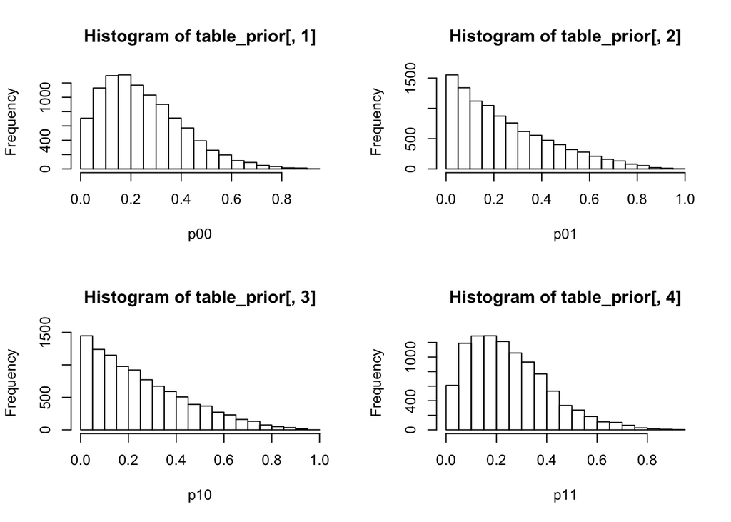

Average cell probablities are (0.25, 0.25, 0.25, 0.25). Large values for cell probabilities are rare. Prior to seeing any data, the model expects counts to be evenly distributed across the four cells.

We now simulate a 2x2 table based on 500 pairs of test results according to the model specifications mentioned above, namely a disease prevalence of 0.2 and sensitivity and specificity of 0.95 and 0.99 for each of the two swabs. The observed data are

```
##         T_1 = 0 T_1 = 1
## T_2 = 0     400       7
## T_2 = 1       2      91
```

We now analyze these data by drawing 8000 parameter values from the joint posterior distribution of all the model parameters. We then compute quantities of interest such as posterior means or intervals directly from these 8000 draws.

We make draws from the posterior distribution using the Stan probablistic programming language and its interface with the R programming language, rstan.

The following table shows estimated posterior means, standard deviations, and selected quantiles for the cell probabilities.

```
##     mean   sd 2.5%  25%  50%  75% 97.5%
## p00 0.80 0.02 0.76 0.78 0.80 0.81  0.83
## p01 0.01 0.00 0.00 0.00 0.01 0.01  0.02
## p10 0.02 0.01 0.01 0.01 0.02 0.02  0.03
## p11 0.18 0.02 0.15 0.17 0.18 0.19  0.21
```

We can also visualize the shape of the posterior distribution by plotting the draws, similar to how we did for the prior distribution. As an example, we focus on the posterior distribution for $p_{00}$. The following figure shows the prior distribution for $p_{00}$ in blue and the posterior distribution for $p_{00}$ in red.

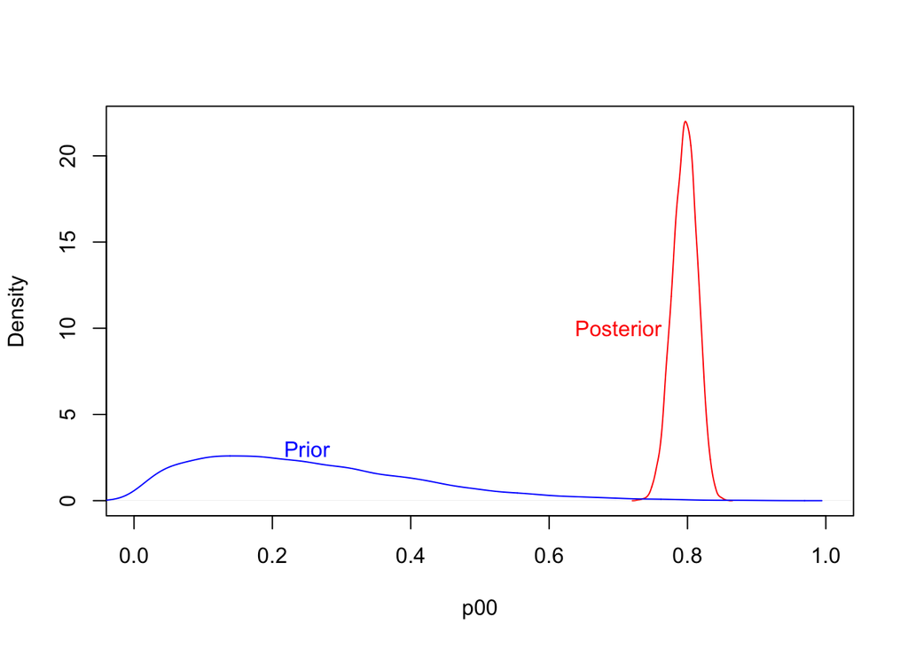

We can see that the posterior distribution for $p_{00}$ has shifted quite a bit relative to the prior distribution and is centered near the true value of 0.78. Despite the prior distribution putting a great deal of weight on smaller values of $p_{00}$, the posterior distribution has been able to learn from the data and update the prior accordingly.

We now “zoom in” on just the posterior distribution. The vertical lines show the true value of $p_{00}$ (the dashed vertical black line), the empirical estimate of $p_{00}$ based on the cell counts alone (the solid black line), and the posterior mean of $p_{00}$ (the solid red line).

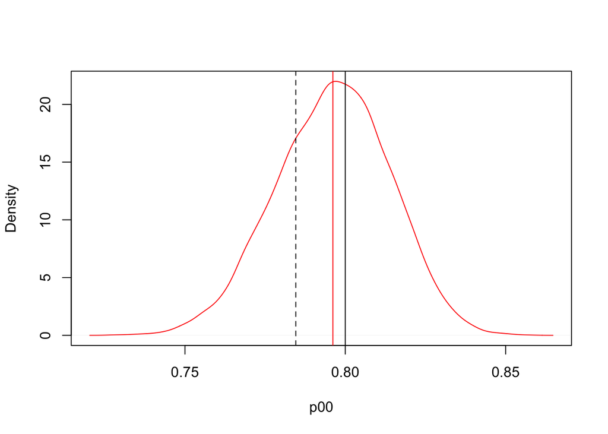

We can see from this plot that the posterior mean tracks very closely with the empirical estimate. Bayesian and frequentist analyses tend to produce similar estimates when prior information is weak and the amount of data is large relative to the model’s complexity (as it is in this case).

The posterior for other quantities of interest can be calculated from the posterior draws as well. For instance, since $P(Agree) = p_{00} + p_{11}$, we can simply add the draws for $p_{00}$ and $p_{11}$ to produce 8000 draws from the posterior distribution of $P(Agree)$. We plot the posterior distribution for $P(Agree)$ below.

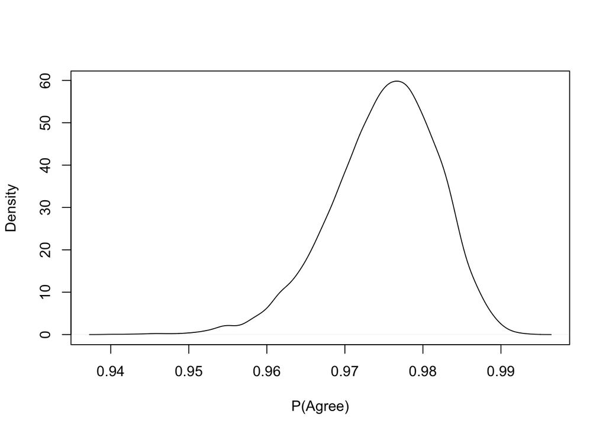

We can then directly assess our degree of evidence for statements such $P(Agree) > 0.95$. Based on our model and the data we’ve observed, the posterior probability that $P(Agree)$ is greater than 0.95 is 1.

We can also consider multiple endpoints at once by looking at the *joint* posterior distribution of parameters. As an example, let’s look at percent negative agreement $PNA = \frac{p_{00}}{p_{00} + p_{01}}$ and percent positive agreement $PPA = \frac{p_{11}}{p_{11} + p_{10}}$. The joint posterior distribution for these outcomes is shown below.

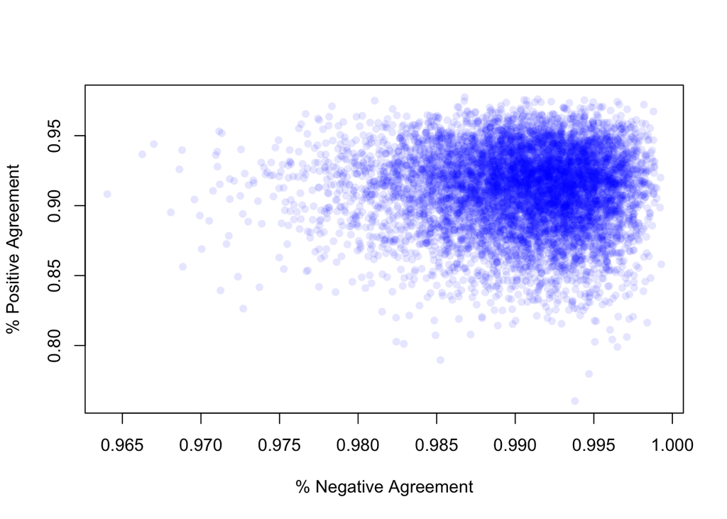

We can calculate posterior probabilities for joint events based on this joint posterior distribution. For instance, $P(\text{% Negative Agreement } > .95 \text{ and % Positive Agreement } > .95 \mid \text{data})$ = 0.07, indicating a low posterior probability for both high (greater than 95%) positive and negative agreement.

## Variation across Testing Sites

Since measures of agreement between two non-gold standard tests depend on both the characteristics of the test and the underlying prevalence of disease in the population being tested, variation in prevalence across different testing sites will result in varying degrees of test agreement even if the sensitivities/specificities of the tests are constant across sites. Since we expect underlying prevalence to vary across sites due to the nature of outbreaks of infectious disease, using data from different sites to estimate a single measure of concordance will fail to capture this variability and may provide an inaccurate picture of what the expected degree of agreement at any one site may look like. At the same time, we do not expect sites to have arbitrarily different degrees of agreement between the tests. We expect sites that have similar underlying disease prevalence to have similar measures of test agreement for a given SoC/Alt swab comparison. Hence, to only use data collected at a particular site to estimate test agreement at that site may be an inefficient use of valuable data.

We can use a multilevel/hierarchical modeling approach to address variability in test agreement due to variability in prevalence across sites while still allowing for some degree of “data sharing” across sites. In our hierarchical model, the $j^{th}$ site is allowed to have its own distinct distribution of cell probabilities $\boldsymbol{p}_j = (p_{00 \cdot j}, p_{01 \cdot j}, p_{10 \cdot j}, p_{11 \cdot j})$. At the same time, the sources of variation in cell probabilities across sites are modeled as arising from a common distribution. In this way, sites are able to “borrow strength” from each other while still being allowed to have their own site-specific levels of test agreement. Moreover, the degree to which sites can borrow strength from each other is itself learned from the data.

We now illustrate this appraoch with another example. We simulate replications of the basic SoC/Alt swab comparison experiment at 20 sites. At each site, 200 people are tested for a total sample size of 4000. For this example, we assume that the SoC and Alt swab sensitivities and specificites are the same across sites. The sensitivities and specificities for each test are set to 0.95 and 0.99, respectively. Underlying disease prevalences were generated by

- drawing 20 random variates $z_j$ from a $Normal(-2, 1)$ distribution
- setting $p_{D \cdot j} = \frac{e^{z_j}}{1 + e^{z_j}}$

The following figure shows the implied distribution of disease prevalences across sites

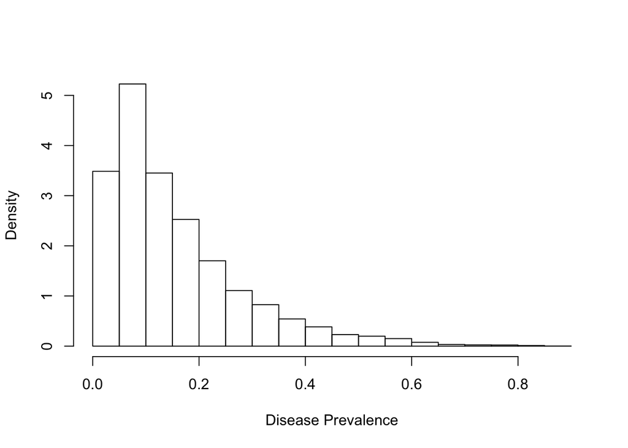

Under this distribution, the bulk of sites have low disease prevalence, with a few sites having disease prevalences at or above 50%.

```
##        T1 = 0 T1 = 1
## T2 = 0     81      6
## T2 = 1      4    109
```

```
##        T1 = 0 T1 = 1
## T2 = 0    185      2
## T2 = 1      3     10
```

```
##        T1 = 0 T1 = 1
## T2 = 0    166      1
## T2 = 1      5     28
```

We then fit the following hierarchical model

$$\begin{align*}
\boldsymbol{X}_j &\mid \boldsymbol{p}_j \sim Multinomial(200, \boldsymbol{p}_j) \\
Sens_t &\sim Uniform(0.5, 1) \\
Spec_t &\sim Uniform(0.5, 1) \\
z_j &\sim Normal(\mu, \sigma^2) \\
\mu &\sim Normal(0, 1) \\
\sigma &\sim Exp(1) \\
p_{D \cdot j} &= \frac{e^{z_j}}{1 + exp(e^{j})} \\
\boldsymbol{p}_j &= f(Sens_1, Sens_2, Spec_1, Spec_2, p_{D \cdot j})
\end{align*}$$
where $f$ is the function that maps the sensitivities/specificities of the tests and the underlying disease prevalence to the cell probabilities through the equations shown in the beginning of the document.

We fit this model using Stan and obtained 4000 draws from the joint posterior distribution of the model parameters. The site-specific posterior distributions for $P(Agree)$ are shown below.

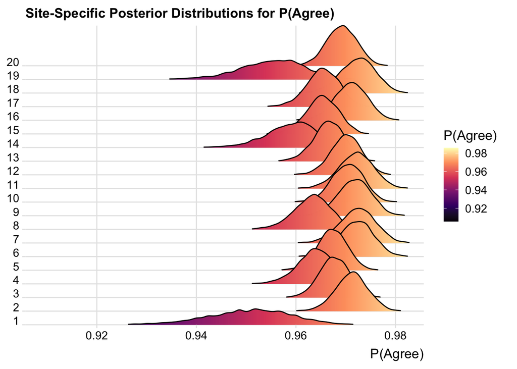

## Benefits of Bayesian Approach

- Ability to incorporate prior knowledge of disease prevalence and swab characteristics
- Ability to think in terms of a “generative” model that reflects what we know about how the test results arise
- More easily handles multilevel/hierarchical nature of the data e.g. variation in agreement measures across sites due to different underlying disease prevalences
- Can more easily generate site-specific predictions with measures of uncertainty
- Flexibility with regards to sequential nature of data
- Direct assessment of uncertainty around questions of interest
- Straightforward joint inference for multiple outcomes

## Drawbacks of Bayesian Approach

- Need to specify prior
- Standard frequentist guarantees about error rates may not apply (can investigate via simulation)
- Pragmatic concern: regulatory approval